# EasyVisa Project

## Context:

Business communities in the United States are facing high demand for human resources, but one of the constant challenges is identifying and attracting the right talent, which is perhaps the most important element in remaining competitive. Companies in the United States look for hard-working, talented, and qualified individuals both locally as well as abroad.

The Immigration and Nationality Act (INA) of the US permits foreign workers to come to the United States to work on either a temporary or permanent basis. The act also protects US workers against adverse impacts on their wages or working conditions by ensuring US employers' compliance with statutory requirements when they hire foreign workers to fill workforce shortages. The immigration programs are administered by the Office of Foreign Labor Certification (OFLC).

OFLC processes job certification applications for employers seeking to bring foreign workers into the United States and grants certifications in those cases where employers can demonstrate that there are not sufficient US workers available to perform the work at wages that meet or exceed the wage paid for the occupation in the area of intended employment.

## Objective:

In FY 2016, the OFLC processed 775,979 employer applications for 1,699,957 positions for temporary and permanent labor certifications. This was a nine percent increase in the overall number of processed applications from the previous year. The process of reviewing every case is becoming a tedious task as the number of applicants is increasing every year.

The increasing number of applicants every year calls for a Machine Learning based solution that can help in shortlisting the candidates having higher chances of VISA approval. OFLC has hired your firm EasyVisa for data-driven solutions. You as a data scientist have to analyze the data provided and, with the help of a classification model:

- Facilitate the process of visa approvals.
- Recommend a suitable profile for the applicants for whom the visa should be certified or denied based on the drivers that significantly influence the case status.

## Data Description

The data contains the different attributes of the employee and the employer. The detailed data dictionary is given below.

- case_id: ID of each visa application
- continent: Information of continent the employee
- education_of_employee: Information of education of the employee
- has_job_experience: Does the employee has any job experience? Y= Yes; N = No
- requires_job_training: Does the employee require any job training? Y = Yes; N = No
- no_of_employees: Number of employees in the employer's company
- yr_of_estab: Year in which the employer's company was established
- region_of_employment: Information of foreign worker's intended region of employment in the US.
- prevailing_wage: Average wage paid to similarly employed workers in a specific occupation in the area of intended employment. The purpose of the prevailing wage is to ensure that the foreign worker is not underpaid compared to other workers offering the same or similar service in the same area of employment.
- unit_of_wage: Unit of prevailing wage. Values include Hourly, Weekly, Monthly, and Yearly.
- full_time_position: Is the position of work full-time? Y = Full Time Position; N = Part Time Position
- case_status: Flag indicating if the Visa was certified or denied

## Importing necessary libraries and data

```python
# To filter the warnings
import warnings

warnings.filterwarnings("ignore")
from statsmodels.tools.sm_exceptions import ConvergenceWarning

warnings.simplefilter("ignore", ConvergenceWarning)

# to help with reading and manipulating data
import pandas as pd
import numpy as np

# for visualizing data
import matplotlib.pyplot as plt
import seaborn as sns

# For randomized data splitting & grid search
from sklearn.model_selection import GridSearchCV, train_test_split

# To build models
from sklearn.tree import DecisionTreeClassifier
from sklearn.ensemble import BaggingClassifier,RandomForestClassifier, GradientBoostingClassifier, AdaBoostClassifier, StackingClassifier
from xgboost import XGBClassifier
from sklearn.linear_model import LogisticRegression

# Removes the limit for the number of displayed columns
pd.set_option("display.max_columns", None)
# Sets the limit for the number of displayed rows
pd.set_option("display.max_rows", 200)

# To get diferent metric scores
from sklearn import metrics
from sklearn.metrics import r2_score, mean_squared_error, mean_absolute_error
from sklearn.metrics import accuracy_score, roc_curve, confusion_matrix, roc_auc_score, f1_score, recall_score, precision_score, plot_confusion_matrix, precision_recall_curve, make_scorer
```

```python
# import the dataset
from google.colab import files
import io

try:
  uploaded
except NameError:
  uploaded = files.upload()

data = pd.read_csv(io.BytesIO(uploaded["EasyVisa.csv"]))
```

```
Saving EasyVisa.csv to EasyVisa.csv
```

```python
# make a copy of the dataset
copy = data.copy()
```

## Data Overview

- Observations
- Sanity checks

```python
# view first 5 rows
data.head()
```

|  | case_id | continent | education_of_employee | has_job_experience | requires_job_training | no_of_employees | yr_of_estab | region_of_employment | prevailing_wage | unit_of_wage | full_time_position | case_status |
| --- | --- | --- | --- | --- | --- | --- | --- | --- | --- | --- | --- | --- |
| 0 | EZYV01 | Asia | High School | N | N | 14513 | 2007 | West | 592.2029 | Hour | Y | Denied |
| 1 | EZYV02 | Asia | Master's | Y | N | 2412 | 2002 | Northeast | 83425.6500 | Year | Y | Certified |
| 2 | EZYV03 | Asia | Bachelor's | N | Y | 44444 | 2008 | West | 122996.8600 | Year | Y | Denied |
| 3 | EZYV04 | Asia | Bachelor's | N | N | 98 | 1897 | West | 83434.0300 | Year | Y | Denied |
| 4 | EZYV05 | Africa | Master's | Y | N | 1082 | 2005 | South | 149907.3900 | Year | Y | Certified |

```python
# view last 5 rows
data.tail()
```

|  | case_id | continent | education_of_employee | has_job_experience | requires_job_training | no_of_employees | yr_of_estab | region_of_employment | prevailing_wage | unit_of_wage | full_time_position | case_status |
| --- | --- | --- | --- | --- | --- | --- | --- | --- | --- | --- | --- | --- |
| 25475 | EZYV25476 | Asia | Bachelor's | Y | Y | 2601 | 2008 | South | 77092.57 | Year | Y | Certified |
| 25476 | EZYV25477 | Asia | High School | Y | N | 3274 | 2006 | Northeast | 279174.79 | Year | Y | Certified |
| 25477 | EZYV25478 | Asia | Master's | Y | N | 1121 | 1910 | South | 146298.85 | Year | N | Certified |
| 25478 | EZYV25479 | Asia | Master's | Y | Y | 1918 | 1887 | West | 86154.77 | Year | Y | Certified |
| 25479 | EZYV25480 | Asia | Bachelor's | Y | N | 3195 | 1960 | Midwest | 70876.91 | Year | Y | Certified |

```python
# understand the data shape
data.shape
```

```
(25480, 12)
```

There are only 12 columns, but there are 25,480 rows

```python
data.info()
```

```
<class 'pandas.core.frame.DataFrame'>
RangeIndex: 25480 entries, 0 to 25479
Data columns (total 12 columns):
 #   Column                 Non-Null Count  Dtype
---  ------                 --------------  -----
 0   case_id                25480 non-null  object
 1   continent              25480 non-null  object
 2   education_of_employee  25480 non-null  object
 3   has_job_experience     25480 non-null  object
 4   requires_job_training  25480 non-null  object
 5   no_of_employees        25480 non-null  int64
 6   yr_of_estab            25480 non-null  int64
 7   region_of_employment   25480 non-null  object
 8   prevailing_wage        25480 non-null  float64
 9   unit_of_wage           25480 non-null  object
 10  full_time_position     25480 non-null  object
 11  case_status            25480 non-null  object
dtypes: float64(1), int64(2), object(9)
memory usage: 2.3+ MB
```

```python
# check for nulls
data.isnull().values.any()
```

```
False
```

Observation: There are no nulls in our dataset.

```python
# print the statistical summary for each variable
data.describe(include='all').T
```

|  | count | unique | top | freq | mean | std | min | 25% | 50% | 75% | max |
| --- | --- | --- | --- | --- | --- | --- | --- | --- | --- | --- | --- |
| case_id | 25480 | 25480 | EZYV01 | 1 | NaN | NaN | NaN | NaN | NaN | NaN | NaN |
| continent | 25480 | 6 | Asia | 16861 | NaN | NaN | NaN | NaN | NaN | NaN | NaN |
| education_of_employee | 25480 | 4 | Bachelor's | 10234 | NaN | NaN | NaN | NaN | NaN | NaN | NaN |
| has_job_experience | 25480 | 2 | Y | 14802 | NaN | NaN | NaN | NaN | NaN | NaN | NaN |
| requires_job_training | 25480 | 2 | N | 22525 | NaN | NaN | NaN | NaN | NaN | NaN | NaN |
| no_of_employees | 25480.0 | NaN | NaN | NaN | 5667.04321 | 22877.928848 | -26.0 | 1022.0 | 2109.0 | 3504.0 | 602069.0 |
| yr_of_estab | 25480.0 | NaN | NaN | NaN | 1979.409929 | 42.366929 | 1800.0 | 1976.0 | 1997.0 | 2005.0 | 2016.0 |
| region_of_employment | 25480 | 5 | Northeast | 7195 | NaN | NaN | NaN | NaN | NaN | NaN | NaN |
| prevailing_wage | 25480.0 | NaN | NaN | NaN | 74455.814592 | 52815.942327 | 2.1367 | 34015.48 | 70308.21 | 107735.5125 | 319210.27 |
| unit_of_wage | 25480 | 4 | Year | 22962 | NaN | NaN | NaN | NaN | NaN | NaN | NaN |
| full_time_position | 25480 | 2 | Y | 22773 | NaN | NaN | NaN | NaN | NaN | NaN | NaN |
| case_status | 25480 | 2 | Certified | 17018 | NaN | NaN | NaN | NaN | NaN | NaN | NaN |

Observations:

- Visa applicants come from 6 different continents.
- They have varying levels of education (4) but Bachelor's degree is the most common.
- Most have job experience.
- There's an average of 5,667 employees at the employing companies. But we see the min is -26, which does not seem accurate. We will have to take care of these values later.
- The average prevailing wage for a position is $74,455.81
- More often than not, the case status is Certified.

## Exploratory Data Analysis (EDA)

- EDA is an important part of any project involving data.
- It is important to investigate and understand the data better before building a model with it.
- A few questions have been mentioned below which will help you approach the analysis in the right manner and generate insights from the data.
- A thorough analysis of the data, in addition to the questions mentioned below, should be done.

### Univariate Analysis

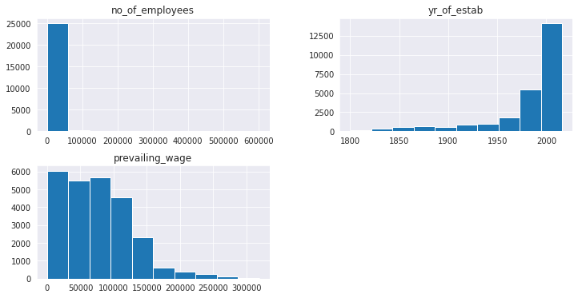

```python
# plot the distributions for numeric variables
sns.set_style("darkgrid")
data.hist(figsize=(12,6))
plt.show()
```

Observations:

- Most companies hiring foreign workers have more than 0 but less than 100,000 employees.
- Most companies were established around or after 2000.
- The prevailing wage for the position is typically between $0-$150,000.

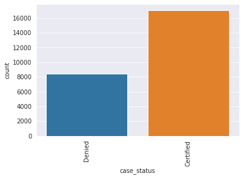

```python
# visualize the categorical variables

sns.countplot(data=data, x='case_status')
plt.xticks(rotation=90);
```

```python
data['case_status'].value_counts(normalize="True")
```

```
Certified    0.667896
Denied       0.332104
Name: case_status, dtype: float64
```

Observation: About 2/3 of cases are Certified and the othe 1/3 are Denied

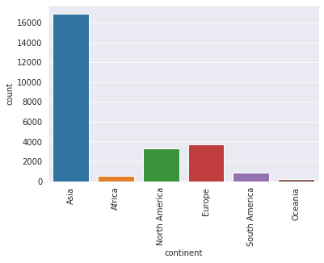

```python
sns.countplot(data=data, x='continent')
plt.xticks(rotation=90);
```

Observation: Most applicants come from Asia, with the least amount of applicants from Oceania.

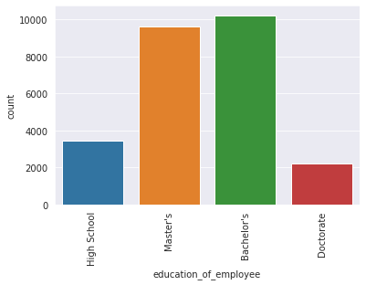

```python
sns.countplot(data=data, x='education_of_employee')
plt.xticks(rotation=90);
```

Observation: Most applicants have a Bachelor's degree, followed closely by those that have a Master's Degree. There are the fewest number of applicants with Doctorate's.

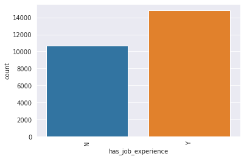

```python
sns.countplot(data=data, x='has_job_experience')
plt.xticks(rotation=90);
```

Observation: More than half of applicants have job experience.

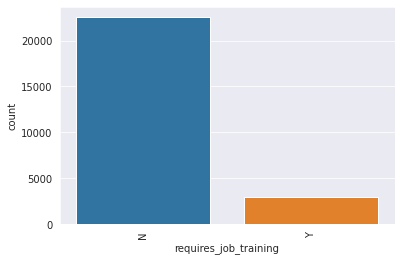

```python
sns.countplot(data=data, x='requires_job_training')
plt.xticks(rotation=90);
```

Observation: Most jobs do not require training.

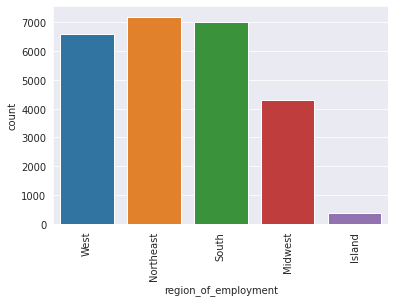

```python
sns.countplot(data=data, x='region_of_employment')
plt.xticks(rotation=90);
```

Observation: Most positions are located in the Northeast, South, or West.

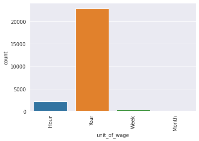

```python
sns.countplot(data=data, x='unit_of_wage')
plt.xticks(rotation=90);
```

Observation: Positions with yearly wages (or annual salaries) are the most common types offering visa sponsorship.

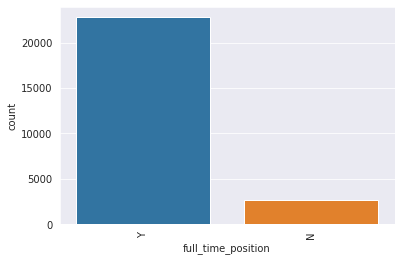

```python
sns.countplot(data=data, x='full_time_position')
plt.xticks(rotation=90);
```

Observation: Most positions offering sponsorshop are full-time positions.

### Bivariate Analysis

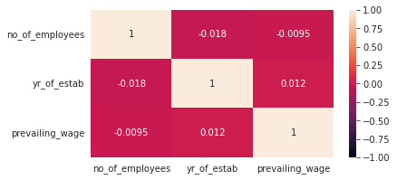

```python
# check correlations

plt.figure(figsize=(6, 3))
sns.heatmap(data.corr(), annot=True, vmin=-1, vmax=1)
plt.show()
```

**Leading Questions**:

1. Those with higher education may want to travel abroad for a well-paid job. Does education play a role in Visa certification?
2. How does the visa status vary across different continents?
3. Experienced professionals might look abroad for opportunities to improve their lifestyles and career development. Does work experience influence visa status?
4. In the United States, employees are paid at different intervals. Which pay unit is most likely to be certified for a visa?
5. The US government has established a prevailing wage to protect local talent and foreign workers. How does the visa status change with the prevailing wage?

### Q1: Those with higher education may want to travel abroad for a well-paid job. Does education play a role in Visa certification?

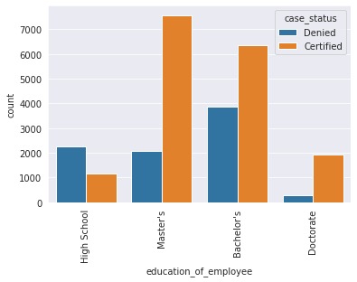

```python
# visualize education level by case status
sns.countplot(data=data, x='education_of_employee', hue = 'case_status')
plt.xticks(rotation=90);
```

Observations: There are more applicants with a Bachelor's degree than any other degrees, but Master's degrees are the second highest. However, it does look like the higher the education an applicant has, the higher chance of their visa being approved.

### Q2: How does the visa status vary across different continents?

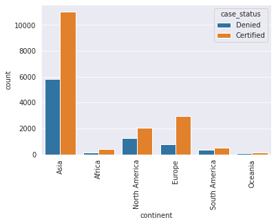

```python
# visualize continents by case status
sns.countplot(data=data, x='continent', hue = 'case_status')
plt.xticks(rotation=90);
```

```python
# get %s
data.groupby('continent')['case_status'].value_counts(normalize="True")
```

```
continent      case_status
Africa         Certified      0.720508
               Denied         0.279492
Asia           Certified      0.653105
               Denied         0.346895
Europe         Certified      0.792337
               Denied         0.207663
North America  Certified      0.618773
               Denied         0.381227
Oceania        Certified      0.635417
               Denied         0.364583
South America  Certified      0.578638
               Denied         0.421362
Name: case_status, dtype: float64
```

Observations: Asia has the highest # of applicants, but only 65% are certified. Europe has the second highest # of applicants, but 79% of them are certified.

### Q3: Experienced professionals might look abroad for opportunities to improve their lifestyles and career development. Does work experience influence visa status?

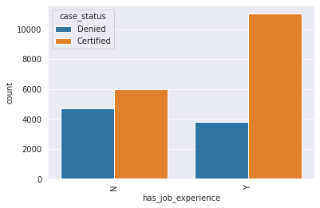

```python
# visualize job experience by case status
sns.countplot(data=data, x='has_job_experience', hue = 'case_status')
plt.xticks(rotation=90);
```

```python
# get counts by case status
data.groupby('has_job_experience')['case_status'].value_counts()
```

```
has_job_experience  case_status
N                   Certified       5994
                    Denied          4684
Y                   Certified      11024
                    Denied          3778
Name: case_status, dtype: int64
```

Observations: There are more experience professionals who apply to work abroad, and if you have experience you are more likely to have your visa certified than if you don't have experience.

### Q4: In the United States, employees are paid at different intervals. Which pay unit is most likely to be certified for a visa?

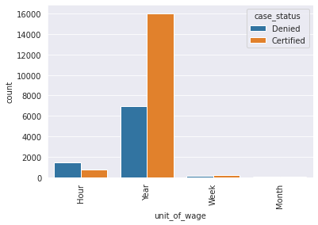

```python
# visualize job experience by case status
sns.countplot(data=data, x='unit_of_wage', hue = 'case_status')
plt.xticks(rotation=90);
```

```python
# get counts by case status
data.groupby('unit_of_wage')['case_status'].value_counts(normalize="True")
```

```
unit_of_wage  case_status
Hour          Denied         0.653686
              Certified      0.346314
Month         Certified      0.617978
              Denied         0.382022
Week          Certified      0.621324
              Denied         0.378676
Year          Certified      0.698850
              Denied         0.301150
Name: case_status, dtype: float64
```

Observations: Positions offering a yearly wage, or annual salary, are the most common type and also the most likely to be certified for a visa.

### Q5: The US government has established a prevailing wage to protect local talent and foreign workers. How does the visa status change with the prevailing wage?

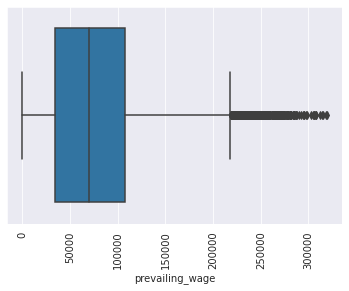

```python
# visualize prevailing wage distribution
sns.boxplot(data=data, x='prevailing_wage')
plt.xticks(rotation=90);
```

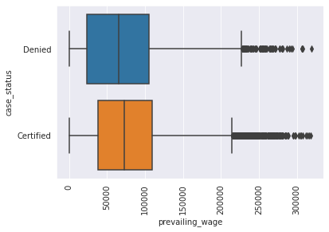

```python
# visualize the prevailing wage by case status
sns.boxplot(data=data, x='prevailing_wage', y='case_status')
plt.xticks(rotation=90);
```

```python
# get overall avg prevailing wage
data['prevailing_wage'].mean()
```

```
74455.81459209183
```

```python
# get avg prevailing wage by case status
data.groupby('case_status')['prevailing_wage'].mean()
```

```
case_status
Certified    77293.619243
Denied       68748.681580
Name: prevailing_wage, dtype: float64
```

Observations: The higher the prevailing wage, the more likely for visa status to be certified.

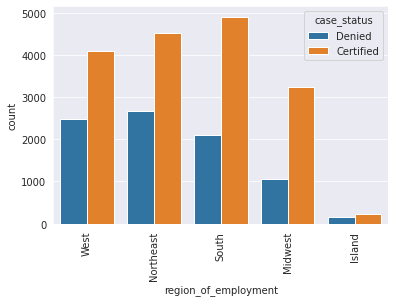

```python
# visualize region of employment by case status
sns.countplot(data=data, x='region_of_employment', hue = 'case_status')
plt.xticks(rotation=90);
```

```python
# get distribution by region of employment
data.groupby('region_of_employment')['case_status'].value_counts(normalize="True")
```

```
region_of_employment  case_status
Island                Certified      0.602667
                      Denied         0.397333
Midwest               Certified      0.755282
                      Denied         0.244718
Northeast             Certified      0.629048
                      Denied         0.370952
South                 Certified      0.700157
                      Denied         0.299843
West                  Certified      0.622533
                      Denied         0.377467
Name: case_status, dtype: float64
```

## Data Preprocessing

- Missing value treatment (if needed)
- Feature engineering
- Outlier detection and treatment (if needed)
- Preparing data for modeling
- Any other preprocessing steps (if needed)

```python
# make another copy of the dataset
df = data.copy()
```

We need to figure out the best way to handle the negative values for number of employees. Let's understand how many records have a negative number of employees.

```python
# check no_of_employees with negative values
neg_emp = data[(data['no_of_employees']<0)]
```

Observation: There are 33 rows with a negative number of employees value. Let's drop them rather than imputing since it's a small number and the imputation will be difficult to understand the best way to approach.

```python
# drop any rows with no of employees <=0
df.drop(df[df['no_of_employees'] <= 0].index, inplace = True)
```

```python
# check the min to make sure it's >0
df['no_of_employees'].min()
```

```
12
```

```python
# re-check no_of_employees with negative values
neg_emp = data[(data['no_of_employees']<0)]
```

Observation: We have dropped the 33 rows with negative number of employees and are ready to proceed with feature engineering.

We have a lot of feature engineering to do for our categorical variables:

- Drop case id
- Get dummies for continent, region of employment
- Change N/Y to 0/1 for job experience, job training, and full time position
- Change target variable case status to 0/1
- Change education of employee and full time position to ordered list

```python
# convert continent
df = pd.get_dummies(df, columns=["continent"])
df.head()
```

|  | case_id | education_of_employee | has_job_experience | requires_job_training | no_of_employees | yr_of_estab | region_of_employment | prevailing_wage | unit_of_wage | full_time_position | case_status | continent_Africa | continent_Asia | continent_Europe | continent_North America | continent_Oceania | continent_South America |
| --- | --- | --- | --- | --- | --- | --- | --- | --- | --- | --- | --- | --- | --- | --- | --- | --- | --- |
| 0 | EZYV01 | High School | N | N | 14513 | 2007 | West | 592.2029 | Hour | Y | Denied | 0 | 1 | 0 | 0 | 0 | 0 |
| 1 | EZYV02 | Master's | Y | N | 2412 | 2002 | Northeast | 83425.6500 | Year | Y | Certified | 0 | 1 | 0 | 0 | 0 | 0 |
| 2 | EZYV03 | Bachelor's | N | Y | 44444 | 2008 | West | 122996.8600 | Year | Y | Denied | 0 | 1 | 0 | 0 | 0 | 0 |
| 3 | EZYV04 | Bachelor's | N | N | 98 | 1897 | West | 83434.0300 | Year | Y | Denied | 0 | 1 | 0 | 0 | 0 | 0 |
| 4 | EZYV05 | Master's | Y | N | 1082 | 2005 | South | 149907.3900 | Year | Y | Certified | 1 | 0 | 0 | 0 | 0 | 0 |

```python
# convert region of employment
df = pd.get_dummies(df, columns=["region_of_employment"])
df.head()
```

|  | case_id | education_of_employee | has_job_experience | requires_job_training | no_of_employees | yr_of_estab | prevailing_wage | unit_of_wage | full_time_position | case_status | continent_Africa | continent_Asia | continent_Europe | continent_North America | continent_Oceania | continent_South America | region_of_employment_Island | region_of_employment_Midwest | region_of_employment_Northeast | region_of_employment_South | region_of_employment_West |
| --- | --- | --- | --- | --- | --- | --- | --- | --- | --- | --- | --- | --- | --- | --- | --- | --- | --- | --- | --- | --- | --- |
| 0 | EZYV01 | High School | N | N | 14513 | 2007 | 592.2029 | Hour | Y | Denied | 0 | 1 | 0 | 0 | 0 | 0 | 0 | 0 | 0 | 0 | 1 |
| 1 | EZYV02 | Master's | Y | N | 2412 | 2002 | 83425.6500 | Year | Y | Certified | 0 | 1 | 0 | 0 | 0 | 0 | 0 | 0 | 1 | 0 | 0 |
| 2 | EZYV03 | Bachelor's | N | Y | 44444 | 2008 | 122996.8600 | Year | Y | Denied | 0 | 1 | 0 | 0 | 0 | 0 | 0 | 0 | 0 | 0 | 1 |
| 3 | EZYV04 | Bachelor's | N | N | 98 | 1897 | 83434.0300 | Year | Y | Denied | 0 | 1 | 0 | 0 | 0 | 0 | 0 | 0 | 0 | 0 | 1 |
| 4 | EZYV05 | Master's | Y | N | 1082 | 2005 | 149907.3900 | Year | Y | Certified | 1 | 0 | 0 | 0 | 0 | 0 | 0 | 0 | 0 | 1 | 0 |

```python
# change the case status to 1/0
df.replace({'Certified': 1, 'Denied': 0}, inplace=True)
df.head()
```

|  | case_id | education_of_employee | has_job_experience | requires_job_training | no_of_employees | yr_of_estab | prevailing_wage | unit_of_wage | full_time_position | case_status | continent_Africa | continent_Asia | continent_Europe | continent_North America | continent_Oceania | continent_South America | region_of_employment_Island | region_of_employment_Midwest | region_of_employment_Northeast | region_of_employment_South | region_of_employment_West |
| --- | --- | --- | --- | --- | --- | --- | --- | --- | --- | --- | --- | --- | --- | --- | --- | --- | --- | --- | --- | --- | --- |
| 0 | EZYV01 | High School | N | N | 14513 | 2007 | 592.2029 | Hour | Y | 0 | 0 | 1 | 0 | 0 | 0 | 0 | 0 | 0 | 0 | 0 | 1 |
| 1 | EZYV02 | Master's | Y | N | 2412 | 2002 | 83425.6500 | Year | Y | 1 | 0 | 1 | 0 | 0 | 0 | 0 | 0 | 0 | 1 | 0 | 0 |
| 2 | EZYV03 | Bachelor's | N | Y | 44444 | 2008 | 122996.8600 | Year | Y | 0 | 0 | 1 | 0 | 0 | 0 | 0 | 0 | 0 | 0 | 0 | 1 |
| 3 | EZYV04 | Bachelor's | N | N | 98 | 1897 | 83434.0300 | Year | Y | 0 | 0 | 1 | 0 | 0 | 0 | 0 | 0 | 0 | 0 | 0 | 1 |
| 4 | EZYV05 | Master's | Y | N | 1082 | 2005 | 149907.3900 | Year | Y | 1 | 1 | 0 | 0 | 0 | 0 | 0 | 0 | 0 | 0 | 1 | 0 |

```python
# change the Y to 1 and 0 to N for 3 columns
df.replace({'Y': 1, 'N': 0}, inplace=True)
df.head()
```

|  | case_id | education_of_employee | has_job_experience | requires_job_training | no_of_employees | yr_of_estab | prevailing_wage | unit_of_wage | full_time_position | case_status | continent_Africa | continent_Asia | continent_Europe | continent_North America | continent_Oceania | continent_South America | region_of_employment_Island | region_of_employment_Midwest | region_of_employment_Northeast | region_of_employment_South | region_of_employment_West |
| --- | --- | --- | --- | --- | --- | --- | --- | --- | --- | --- | --- | --- | --- | --- | --- | --- | --- | --- | --- | --- | --- |
| 0 | EZYV01 | High School | 0 | 0 | 14513 | 2007 | 592.2029 | Hour | 1 | 0 | 0 | 1 | 0 | 0 | 0 | 0 | 0 | 0 | 0 | 0 | 1 |
| 1 | EZYV02 | Master's | 1 | 0 | 2412 | 2002 | 83425.6500 | Year | 1 | 1 | 0 | 1 | 0 | 0 | 0 | 0 | 0 | 0 | 1 | 0 | 0 |
| 2 | EZYV03 | Bachelor's | 0 | 1 | 44444 | 2008 | 122996.8600 | Year | 1 | 0 | 0 | 1 | 0 | 0 | 0 | 0 | 0 | 0 | 0 | 0 | 1 |
| 3 | EZYV04 | Bachelor's | 0 | 0 | 98 | 1897 | 83434.0300 | Year | 1 | 0 | 0 | 1 | 0 | 0 | 0 | 0 | 0 | 0 | 0 | 0 | 1 |
| 4 | EZYV05 | Master's | 1 | 0 | 1082 | 2005 | 149907.3900 | Year | 1 | 1 | 1 | 0 | 0 | 0 | 0 | 0 | 0 | 0 | 0 | 1 | 0 |

```python
# drop the case_id column
df.drop('case_id', axis=1, inplace=True)
df.head()
```

|  | education_of_employee | has_job_experience | requires_job_training | no_of_employees | yr_of_estab | prevailing_wage | unit_of_wage | full_time_position | case_status | continent_Africa | continent_Asia | continent_Europe | continent_North America | continent_Oceania | continent_South America | region_of_employment_Island | region_of_employment_Midwest | region_of_employment_Northeast | region_of_employment_South | region_of_employment_West |
| --- | --- | --- | --- | --- | --- | --- | --- | --- | --- | --- | --- | --- | --- | --- | --- | --- | --- | --- | --- | --- |
| 0 | High School | 0 | 0 | 14513 | 2007 | 592.2029 | Hour | 1 | 0 | 0 | 1 | 0 | 0 | 0 | 0 | 0 | 0 | 0 | 0 | 1 |
| 1 | Master's | 1 | 0 | 2412 | 2002 | 83425.6500 | Year | 1 | 1 | 0 | 1 | 0 | 0 | 0 | 0 | 0 | 0 | 1 | 0 | 0 |
| 2 | Bachelor's | 0 | 1 | 44444 | 2008 | 122996.8600 | Year | 1 | 0 | 0 | 1 | 0 | 0 | 0 | 0 | 0 | 0 | 0 | 0 | 1 |
| 3 | Bachelor's | 0 | 0 | 98 | 1897 | 83434.0300 | Year | 1 | 0 | 0 | 1 | 0 | 0 | 0 | 0 | 0 | 0 | 0 | 0 | 1 |
| 4 | Master's | 1 | 0 | 1082 | 2005 | 149907.3900 | Year | 1 | 1 | 1 | 0 | 0 | 0 | 0 | 0 | 0 | 0 | 0 | 1 | 0 |

```python
# change the education to 1-4
df.replace({"High School": 1, "Bachelor's": 2, "Master's": 3, "Doctorate": 4}, inplace=True)
df.head()
```

|  | education_of_employee | has_job_experience | requires_job_training | no_of_employees | yr_of_estab | prevailing_wage | unit_of_wage | full_time_position | case_status | continent_Africa | continent_Asia | continent_Europe | continent_North America | continent_Oceania | continent_South America | region_of_employment_Island | region_of_employment_Midwest | region_of_employment_Northeast | region_of_employment_South | region_of_employment_West |
| --- | --- | --- | --- | --- | --- | --- | --- | --- | --- | --- | --- | --- | --- | --- | --- | --- | --- | --- | --- | --- |
| 0 | 1 | 0 | 0 | 14513 | 2007 | 592.2029 | Hour | 1 | 0 | 0 | 1 | 0 | 0 | 0 | 0 | 0 | 0 | 0 | 0 | 1 |
| 1 | 3 | 1 | 0 | 2412 | 2002 | 83425.6500 | Year | 1 | 1 | 0 | 1 | 0 | 0 | 0 | 0 | 0 | 0 | 1 | 0 | 0 |
| 2 | 2 | 0 | 1 | 44444 | 2008 | 122996.8600 | Year | 1 | 0 | 0 | 1 | 0 | 0 | 0 | 0 | 0 | 0 | 0 | 0 | 1 |
| 3 | 2 | 0 | 0 | 98 | 1897 | 83434.0300 | Year | 1 | 0 | 0 | 1 | 0 | 0 | 0 | 0 | 0 | 0 | 0 | 0 | 1 |
| 4 | 3 | 1 | 0 | 1082 | 2005 | 149907.3900 | Year | 1 | 1 | 1 | 0 | 0 | 0 | 0 | 0 | 0 | 0 | 0 | 1 | 0 |

```python
# change the wage unit to 1-4
df.replace({"Hour": 1, "Week": 2, "Month": 3, "Year": 4}, inplace=True)
df.head()
```

|  | education_of_employee | has_job_experience | requires_job_training | no_of_employees | yr_of_estab | prevailing_wage | unit_of_wage | full_time_position | case_status | continent_Africa | continent_Asia | continent_Europe | continent_North America | continent_Oceania | continent_South America | region_of_employment_Island | region_of_employment_Midwest | region_of_employment_Northeast | region_of_employment_South | region_of_employment_West |
| --- | --- | --- | --- | --- | --- | --- | --- | --- | --- | --- | --- | --- | --- | --- | --- | --- | --- | --- | --- | --- |
| 0 | 1 | 0 | 0 | 14513 | 2007 | 592.2029 | 1 | 1 | 0 | 0 | 1 | 0 | 0 | 0 | 0 | 0 | 0 | 0 | 0 | 1 |
| 1 | 3 | 1 | 0 | 2412 | 2002 | 83425.6500 | 4 | 1 | 1 | 0 | 1 | 0 | 0 | 0 | 0 | 0 | 0 | 1 | 0 | 0 |
| 2 | 2 | 0 | 1 | 44444 | 2008 | 122996.8600 | 4 | 1 | 0 | 0 | 1 | 0 | 0 | 0 | 0 | 0 | 0 | 0 | 0 | 1 |
| 3 | 2 | 0 | 0 | 98 | 1897 | 83434.0300 | 4 | 1 | 0 | 0 | 1 | 0 | 0 | 0 | 0 | 0 | 0 | 0 | 0 | 1 |
| 4 | 3 | 1 | 0 | 1082 | 2005 | 149907.3900 | 4 | 1 | 1 | 1 | 0 | 0 | 0 | 0 | 0 | 0 | 0 | 0 | 1 | 0 |

## EDA

- It is a good idea to explore the data once again after manipulating it.

```python
# check variables
df.describe(include='all').T
```

|  | count | mean | std | min | 25% | 50% | 75% | max |
| --- | --- | --- | --- | --- | --- | --- | --- | --- |
| education_of_employee | 25447.0 | 2.415923 | 0.826729 | 1.0000 | 2.00 | 2.0 | 3.000 | 4.00 |
| has_job_experience | 25447.0 | 0.581051 | 0.493397 | 0.0000 | 0.00 | 1.0 | 1.000 | 1.00 |
| requires_job_training | 25447.0 | 0.115888 | 0.320097 | 0.0000 | 0.00 | 0.0 | 0.000 | 1.00 |
| no_of_employees | 25447.0 | 5674.415334 | 22891.842245 | 12.0000 | 1025.00 | 2112.0 | 3506.500 | 602069.00 |
| yr_of_estab | 25447.0 | 1979.394506 | 42.385932 | 1800.0000 | 1976.00 | 1997.0 | 2005.000 | 2016.00 |
| prevailing_wage | 25447.0 | 74468.281479 | 52822.177370 | 2.1367 | 34039.21 | 70312.5 | 107739.505 | 319210.27 |
| unit_of_wage | 25447.0 | 3.721303 | 0.854444 | 1.0000 | 4.00 | 4.0 | 4.000 | 4.00 |
| full_time_position | 25447.0 | 0.893661 | 0.308277 | 0.0000 | 1.00 | 1.0 | 1.000 | 1.00 |
| case_status | 25447.0 | 0.668094 | 0.470907 | 0.0000 | 0.00 | 1.0 | 1.000 | 1.00 |
| continent_Africa | 25447.0 | 0.021614 | 0.145421 | 0.0000 | 0.00 | 0.0 | 0.000 | 1.00 |
| continent_Asia | 25447.0 | 0.661768 | 0.473117 | 0.0000 | 0.00 | 1.0 | 1.000 | 1.00 |
| continent_Europe | 25447.0 | 0.146461 | 0.353575 | 0.0000 | 0.00 | 0.0 | 0.000 | 1.00 |
| continent_North America | 25447.0 | 0.129170 | 0.335395 | 0.0000 | 0.00 | 0.0 | 0.000 | 1.00 |
| continent_Oceania | 25447.0 | 0.007545 | 0.086536 | 0.0000 | 0.00 | 0.0 | 0.000 | 1.00 |
| continent_South America | 25447.0 | 0.033442 | 0.179791 | 0.0000 | 0.00 | 0.0 | 0.000 | 1.00 |
| region_of_employment_Island | 25447.0 | 0.014737 | 0.120499 | 0.0000 | 0.00 | 0.0 | 0.000 | 1.00 |
| region_of_employment_Midwest | 25447.0 | 0.168939 | 0.374706 | 0.0000 | 0.00 | 0.0 | 0.000 | 1.00 |
| region_of_employment_Northeast | 25447.0 | 0.282509 | 0.450228 | 0.0000 | 0.00 | 0.0 | 1.000 | 1.00 |
| region_of_employment_South | 25447.0 | 0.275317 | 0.446683 | 0.0000 | 0.00 | 0.0 | 1.000 | 1.00 |
| region_of_employment_West | 25447.0 | 0.258498 | 0.437818 | 0.0000 | 0.00 | 0.0 | 1.000 | 1.00 |

```python
# check data types
df.info()
```

```
<class 'pandas.core.frame.DataFrame'>
Int64Index: 25447 entries, 0 to 25479
Data columns (total 20 columns):
 #   Column                          Non-Null Count  Dtype
---  ------                          --------------  -----
 0   education_of_employee           25447 non-null  int64
 1   has_job_experience              25447 non-null  int64
 2   requires_job_training           25447 non-null  int64
 3   no_of_employees                 25447 non-null  int64
 4   yr_of_estab                     25447 non-null  int64
 5   prevailing_wage                 25447 non-null  float64
 6   unit_of_wage                    25447 non-null  int64
 7   full_time_position              25447 non-null  int64
 8   case_status                     25447 non-null  int64
 9   continent_Africa                25447 non-null  uint8
 10  continent_Asia                  25447 non-null  uint8
 11  continent_Europe                25447 non-null  uint8
 12  continent_North America         25447 non-null  uint8
 13  continent_Oceania               25447 non-null  uint8
 14  continent_South America         25447 non-null  uint8
 15  region_of_employment_Island     25447 non-null  uint8
 16  region_of_employment_Midwest    25447 non-null  uint8
 17  region_of_employment_Northeast  25447 non-null  uint8
 18  region_of_employment_South      25447 non-null  uint8
 19  region_of_employment_West       25447 non-null  uint8
dtypes: float64(1), int64(8), uint8(11)
memory usage: 2.2 MB
```

Observation: All of our new columns are there and we can see that everything is represented numerically now. We also see the min of no_of_employees is now 12 and our case_id column has been dropped. Let's do one more quick check of the counts for some of the key categorical variables and then we are ready to move on.

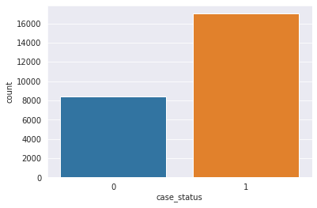

```python
# verify correct distributions of some key categorical variables engineered to make sure the values are accurate
sns.countplot(data=df, x='case_status')
plt.show()
```

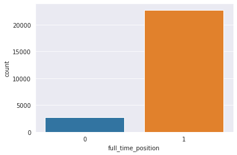

```python
sns.countplot(data=df, x='full_time_position')
plt.show()
```

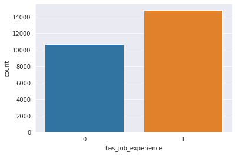

```python
sns.countplot(data=df, x='has_job_experience')
plt.show()
```

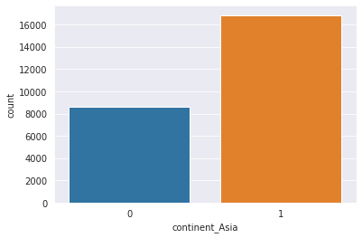

```python
sns.countplot(data=df, x='continent_Asia')
plt.show()
```

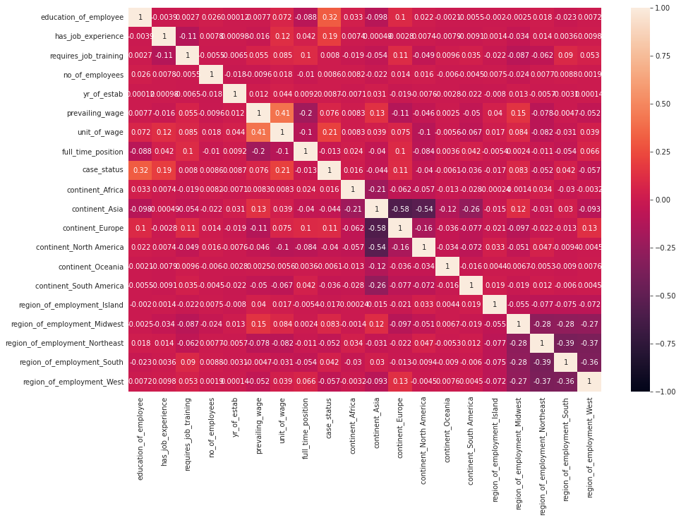

```python
# check correlations

plt.figure(figsize=(15, 10))
sns.heatmap(df.corr(), annot=True, vmin=-1, vmax=1)
plt.show()
```

Observations: We don't observe any very strong correlations between variables.

### Prepare for model building

```python
# Separating features and the target column
X = df.drop('case_status', axis=1)
y = df['case_status']
```

```python
# Splitting the data into train and test sets in 70:30 ratio
X_train, X_test, y_train, y_test = train_test_split(X, y, test_size=0.30, random_state=1, shuffle=True)
```

```python
X_train.shape, X_test.shape
```

```
((17812, 19), (7635, 19))
```

## Building bagging models

### Define functions to calculate/display model performance scores

```python
# Function to create confusion matrix
def make_confusion_matrix(model,y_actual,labels=[1, 0]):
    '''
    model : classifier to predict values of X
    y_actual : ground truth

    '''
    y_predict = model.predict(X_test)
    cm=metrics.confusion_matrix( y_actual, y_predict, labels=[0, 1])
    df_cm = pd.DataFrame(cm, index = [i for i in ["Actual - No","Actual - Yes"]],
                  columns = [i for i in ['Predicted - No','Predicted - Yes']])
    group_counts = ["{0:0.0f}".format(value) for value in
                cm.flatten()]
    group_percentages = ["{0:.2%}".format(value) for value in
                         cm.flatten()/np.sum(cm)]
    labels = [f"{v1}\n{v2}" for v1, v2 in
              zip(group_counts,group_percentages)]
    labels = np.asarray(labels).reshape(2,2)
    plt.figure(figsize = (10,7))
    sns.heatmap(df_cm, annot=labels,fmt='')
    plt.ylabel('True label')
    plt.xlabel('Predicted label')
```

```python
#  Function to calculate different metric scores of the model - Accuracy, Recall and Precision
def get_metrics_score(model,flag=True):
    '''
    model : classifier to predict values of X

    '''
    # defining an empty list to store train and test results
    score_list=[]

    #Predicting on train and tests
    pred_train = model.predict(X_train)
    pred_test = model.predict(X_test)

    #Accuracy of the model
    train_acc = model.score(X_train,y_train)
    test_acc = model.score(X_test,y_test)

    #Recall of the model
    train_recall = metrics.recall_score(y_train,pred_train)
    test_recall = metrics.recall_score(y_test,pred_test)

    #Precision of the model
    train_precision = metrics.precision_score(y_train,pred_train)
    test_precision = metrics.precision_score(y_test,pred_test)

    #F1 score
    train_f1 = metrics.f1_score(y_train,pred_train)
    test_f1 = metrics.f1_score(y_test,pred_test)

    score_list.extend((train_acc,test_acc,train_recall,test_recall,train_precision,test_precision,train_f1,test_f1))

    # If the flag is set to True then only the following print statements will be dispayed. The default value is set to True.
    if flag == True:
        print("Accuracy on training set : ",model.score(X_train,y_train))
        print("Accuracy on test set : ",model.score(X_test,y_test))
        print("Recall on training set : ",metrics.recall_score(y_train,pred_train))
        print("Recall on test set : ",metrics.recall_score(y_test,pred_test))
        print("Precision on training set : ",metrics.precision_score(y_train,pred_train))
        print("Precision on test set : ",metrics.precision_score(y_test,pred_test))
        print("F1 score on training set : ",metrics.f1_score(y_train,pred_train))
        print("F1 score on test set : ",metrics.f1_score(y_test,pred_test))

    return score_list # returning the list with train and test scores
```

### Decision Tree Model

```python
dtree=DecisionTreeClassifier(random_state=1)
dtree.fit(X_train,y_train)
```

```
DecisionTreeClassifier(random_state=1)
```

```python
# Using above defined function to get performance metrics on train and test set
dtree_score=get_metrics_score(dtree)
```

```
Accuracy on training set :  1.0
Accuracy on test set :  0.664309102815979
Recall on training set :  1.0
Recall on test set :  0.7394613583138173
Precision on training set :  1.0
Precision on test set :  0.7552322104843532
F1 score on training set :  1.0
F1 score on test set :  0.7472635834730302
```

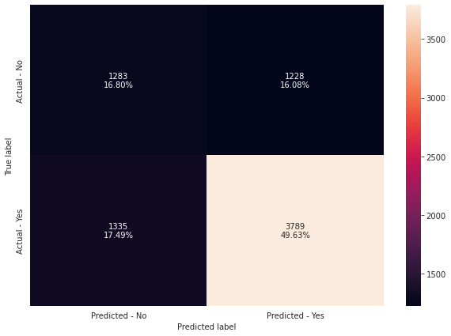

```python
make_confusion_matrix(dtree,y_test)
```

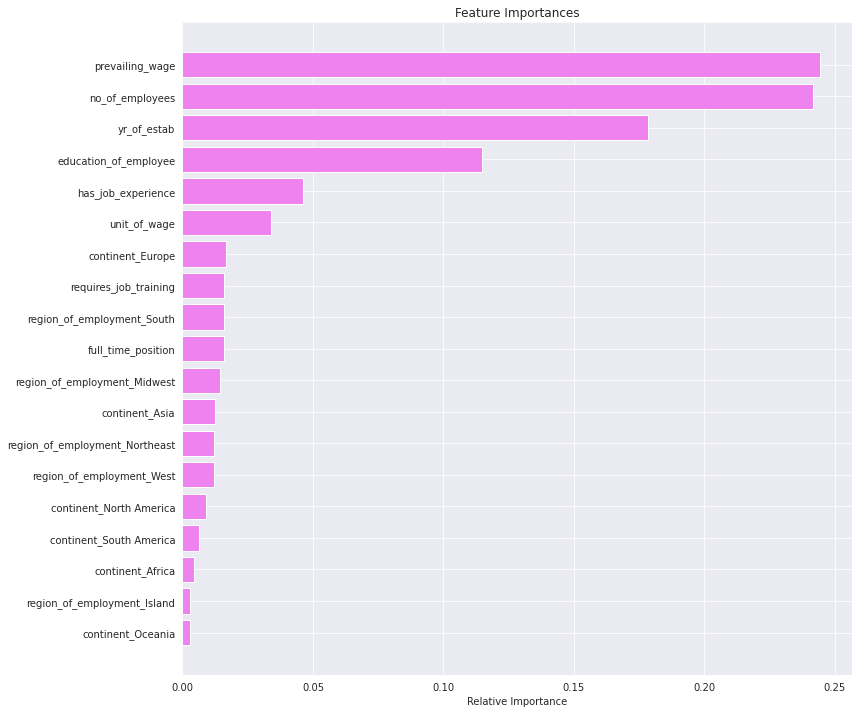

```python
importances = dtree.feature_importances_
indices = np.argsort(importances)
feature_names = list(X.columns)

plt.figure(figsize=(12,12))
plt.title('Feature Importances')
plt.barh(range(len(indices)), importances[indices], color='violet', align='center')
plt.yticks(range(len(indices)), [feature_names[i] for i in indices])
plt.xlabel('Relative Importance')
plt.show()
```

Observations:

- Prevailing wage is the most important feature in this decision tree model.
- We want to maximize our true positives (right now we see 3,789). We don't want to have a lot of false negatives (where we predicted the visa would not certify and it did), but we also don't want a lot of false positives (where we predict the visa would certify but it did not). Both can have a very negative impact on the applicant and the hiring company. So instead, we will choose to maximize the F1 score.
- Right now we see that the decision tree is overfitting the training data. Our F1 score on training is 1 where the F1 score on test is 0.75. Let's try to tune the hyperparameters and see if we can reduce overfitting while improving the F1 score. Then we will try a bagging classifier and a random forest model before we move on to boosting models.

#### Will tuning the hyperparameters improve the model performance?

```python
# Choose the type of classifier.
dtree_tuned = DecisionTreeClassifier(random_state=1)

# Grid of parameters to choose from
parameters = {'max_depth': list(np.arange(2,20)) + [None],
              'min_samples_leaf': [1, 3, 5, 7, 10],
              'max_leaf_nodes' : [2, 3, 5, 10, 15] + [None],
              'min_impurity_decrease': [0.001, 0.01, 0.1, 0.0]
             }

# Type of scoring used to compare parameter combinations
scorer = metrics.make_scorer(metrics.r2_score)

# Run the grid search
grid_obj = GridSearchCV(dtree_tuned, parameters, scoring=scorer,cv=5)
grid_obj = grid_obj.fit(X_train, y_train)

# Set the clf to the best combination of parameters
dtree_tuned = grid_obj.best_estimator_

# Fit the best algorithm to the data.
dtree_tuned.fit(X_train, y_train)
```

```
DecisionTreeClassifier(max_depth=7, max_leaf_nodes=15, random_state=1)
```

```python
# Using above defined function to get performance metrics on train and test set
dtree_tuned_score=get_metrics_score(dtree_tuned)
```

```
Accuracy on training set :  0.7467999101729171
Accuracy on test set :  0.7544204322200393
Recall on training set :  0.865454239286015
Recall on test set :  0.8750975800156128
Precision on training set :  0.7792434235463573
Precision on test set :  0.7840531561461794
F1 score on training set :  0.8200893569490985
F1 score on test set :  0.8270773771096559
```

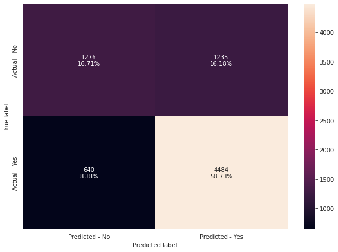

```python
make_confusion_matrix(dtree_tuned,y_test)
```

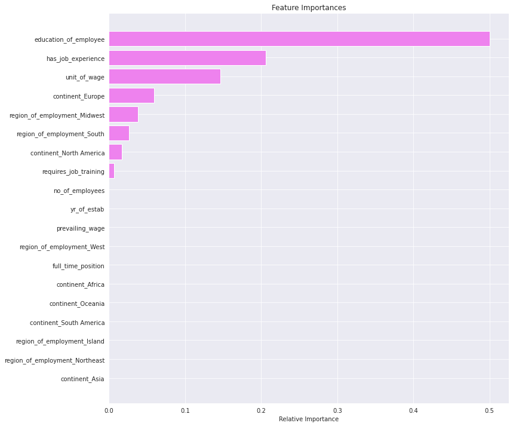

```python
importances = dtree_tuned.feature_importances_
indices = np.argsort(importances)
feature_names = list(X.columns)

plt.figure(figsize=(12,12))
plt.title('Feature Importances')
plt.barh(range(len(indices)), importances[indices], color='violet', align='center')
plt.yticks(range(len(indices)), [feature_names[i] for i in indices])
plt.xlabel('Relative Importance')
plt.show()
```

Observations:

- We were able to significantly improve F1 score on the test set from 0.75 to 0.83 and our model is no longer overfitting.
- We can see that prevailing wage is no longer the most important feature, education level of the employee is.

### Bagging Classifier

```python
#base_estimator for bagging classifier is a decision tree by default
bagging_estimator=BaggingClassifier(random_state=1)
bagging_estimator.fit(X_train,y_train)
```

```
BaggingClassifier(random_state=1)
```

```python
# Using above defined function to get performance metrics on train and test set
bagging_estimator_score=get_metrics_score(bagging_estimator)
```

```
Accuracy on training set :  0.9862452279362228
Accuracy on test set :  0.7058284217419777
Recall on training set :  0.9882125115769975
Recall on test set :  0.7777127244340359
Precision on training set :  0.991133254517818
Precision on test set :  0.7826001571091908
F1 score on training set :  0.9896707281082676
F1 score on test set :  0.7801487862176977
```

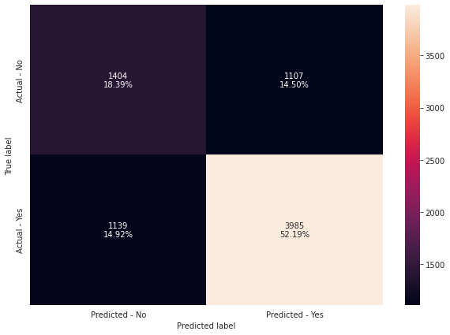

```python
make_confusion_matrix(bagging_estimator,y_test)
```

[Bagging classifier has no feature importance]

Observation: We see that we were able to predict more true positives and increase our F1 score on the test set from 0.75 in the base (default parameters) decision tree model to 0.78, but the model still looks to be overfitting on the training set and the tuned decision tree is performing better. Let's try tuning the hyperparameters for the bagging classifier to see if performance improves.

#### Will tuning the hyperparameters improve the model performance?

```python
# Choose the type of classifier.
bagging_estimator_tuned = BaggingClassifier(random_state=1)

# Grid of parameters to choose from
## add from article
parameters = {'max_samples': [0.7,0.8,0.9,1],
              'max_features': [0.7,0.8,0.9,1],
              'n_estimators' : [10,20,30,40,50],
             }

# Type of scoring used to compare parameter combinations
acc_scorer = metrics.make_scorer(metrics.recall_score)

# Run the grid search
grid_obj = GridSearchCV(bagging_estimator_tuned, parameters, scoring=acc_scorer,cv=5)
grid_obj = grid_obj.fit(X_train, y_train)

# Set the clf to the best combination of parameters
bagging_estimator_tuned = grid_obj.best_estimator_

# Fit the best algorithm to the data.
bagging_estimator_tuned.fit(X_train, y_train)
```

```
BaggingClassifier(max_features=0.7, max_samples=1, random_state=1)
```

```python
# Using above defined function to get performance metrics on train and test set
bagging_estimator_tuned_score=get_metrics_score(bagging_estimator_tuned)
```

```
Accuracy on training set :  0.6667976644958455
Accuracy on test set :  0.6711198428290767
Recall on training set :  1.0
Recall on test set :  1.0
Precision on training set :  0.6667976644958455
Precision on test set :  0.6711198428290767
F1 score on training set :  0.8000943110242851
F1 score on test set :  0.8031977427698095
```

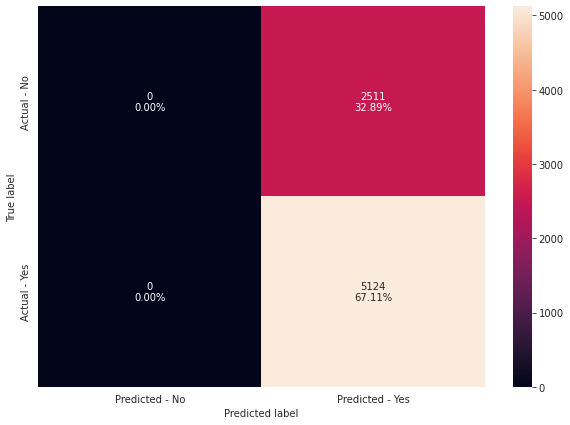

```python
make_confusion_matrix(bagging_estimator_tuned,y_test)
```

Observation: Tuning the hyperparameters increased the F1 score to 0.80 on the test set, from .78 in the base bagging model. Equally as important, we see the F1 score on the training set was also 0.80, so the model is no longer overfitting. However, we seem to just be predicting that the visa will be certified every time which is certainly not true, and we still saw a better score from the tuned decision tree. Let's see if we can improve by using Random Forest.

### Random Forest Model

```python
rf_estimator=RandomForestClassifier(random_state=1)
rf_estimator.fit(X_train,y_train)
```

```
RandomForestClassifier(random_state=1)
```

```python
# Using above defined function to get performance metrics on train and test set
rf_estimator_score=get_metrics_score(rf_estimator)
```

```
Accuracy on training set :  0.9999438580732091
Accuracy on test set :  0.7273084479371317
Recall on training set :  1.0
Recall on test set :  0.8407494145199064
Precision on training set :  0.9999158107425492
Precision on test set :  0.7728740581270183
F1 score on training set :  0.9999579035992422
F1 score on test set :  0.8053841839596186
```

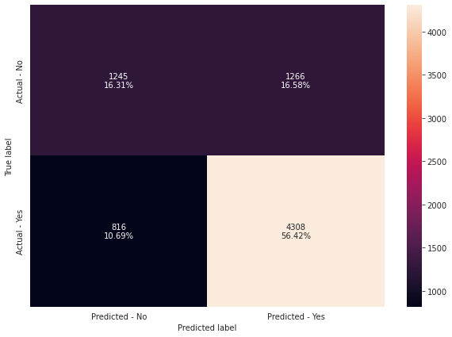

```python
make_confusion_matrix(rf_estimator,y_test)
```

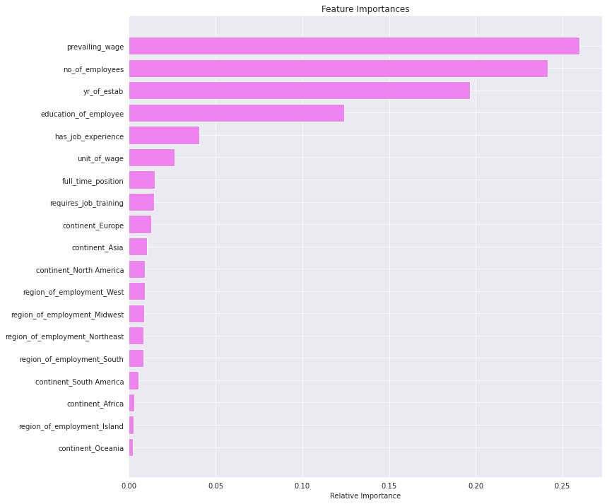

```python
importances = rf_estimator.feature_importances_
indices = np.argsort(importances)
feature_names = list(X.columns)

plt.figure(figsize=(12,12))
plt.title('Feature Importances')
plt.barh(range(len(indices)), importances[indices], color='violet', align='center')
plt.yticks(range(len(indices)), [feature_names[i] for i in indices])
plt.xlabel('Relative Importance')
plt.show()
```

Observations:

- Prevailing wage is once again the most important feature in this model as it was in our base decision tree model.
- We still have around the same F1 score of 0.80 on the test set, but it looks like we are overfitting again on the training set. Let's try to tune the hyperparameters to see if we can improve that.

#### Will tuning the hyperparameters improve the model performance?

```python
# Choose the type of classifier.
rf_estimator_tuned = RandomForestClassifier(random_state=1)

# Grid of parameters to choose from
# add from article
parameters = {"n_estimators": [150,200],
    "min_samples_leaf": np.arange(5, 10),
    "max_features": np.arange(0.2, 0.7),
    "max_samples": np.arange(0.3, 0.7),
             }

# Type of scoring used to compare parameter combinations
acc_scorer = metrics.make_scorer(metrics.recall_score)

# Run the grid search
grid_obj = GridSearchCV(rf_estimator_tuned, parameters, scoring=acc_scorer,cv=5)
grid_obj = grid_obj.fit(X_train, y_train)

# Set the clf to the best combination of parameters
rf_estimator_tuned = grid_obj.best_estimator_

# Fit the best algorithm to the data.
rf_estimator_tuned.fit(X_train, y_train)
```

```
RandomForestClassifier(max_features=0.2, max_samples=0.3, min_samples_leaf=9,
                       n_estimators=200, random_state=1)
```

```python
# Using above defined function to get performance metrics on train and test set
rf_estimator_tuned_score=get_metrics_score(rf_estimator_tuned)
```

```
Accuracy on training set :  0.7566247473613295
Accuracy on test set :  0.7506221349050426
Recall on training set :  0.9010692935926581
Recall on test set :  0.9012490241998439
Precision on training set :  0.7720386668590391
Precision on test set :  0.7676196808510638
F1 score on training set :  0.8315785384047554
F1 score on test set :  0.8290843806104129
```

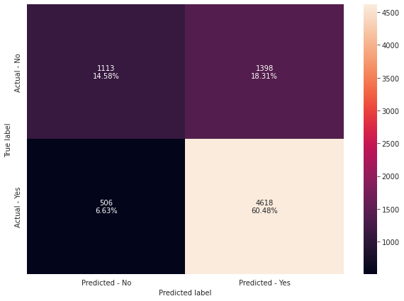

```python
make_confusion_matrix(rf_estimator_tuned,y_test)
```

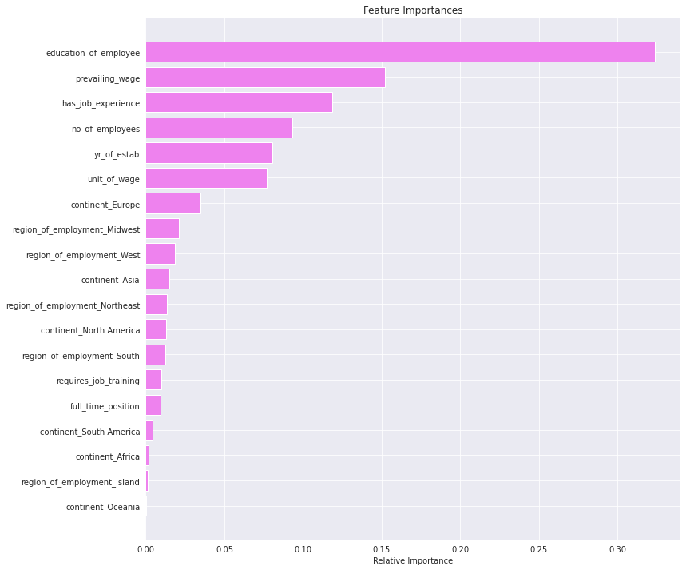

```python
importances = rf_estimator_tuned.feature_importances_
indices = np.argsort(importances)
feature_names = list(X.columns)

plt.figure(figsize=(12,12))
plt.title('Feature Importances')
plt.barh(range(len(indices)), importances[indices], color='violet', align='center')
plt.yticks(range(len(indices)), [feature_names[i] for i in indices])
plt.xlabel('Relative Importance')
plt.show()
```

Observations:

- F1 score increased for the test set to 0.83 which is in-line with the tuned decision tree model performance.
- Also the same in that model, the education level of the employee is once again our top feature.

## Building boosting models

### AdaBoost Classifier

```python
abc = AdaBoostClassifier(random_state=1)
abc.fit(X_train,y_train)
```

```
AdaBoostClassifier(random_state=1)
```

```python
# Using above defined function to get performance metrics on train and test set
abc_score=get_metrics_score(abc)
```

```
Accuracy on training set :  0.7336065573770492
Accuracy on test set :  0.7421087098886706
Recall on training set :  0.883893239033426
Recall on test set :  0.8932474629195941
Precision on training set :  0.7572129255626082
Precision on test set :  0.7629604934155693
F1 score on training set :  0.8156637271279282
F1 score on test set :  0.8229794120291289
```

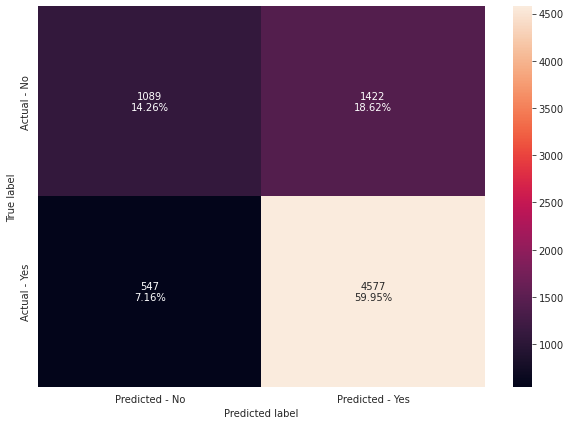

```python
make_confusion_matrix(abc,y_test)
```

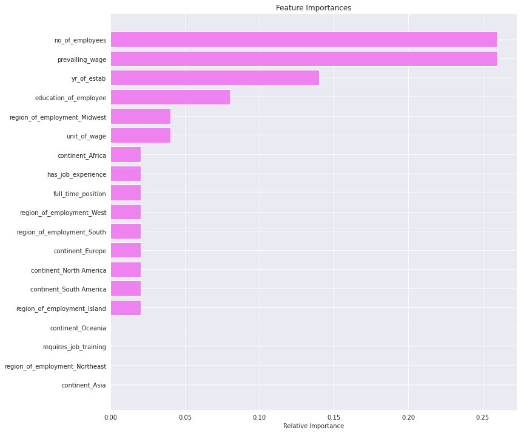

```python
importances = abc.feature_importances_
indices = np.argsort(importances)
feature_names = list(X.columns)

plt.figure(figsize=(12,12))
plt.title('Feature Importances')
plt.barh(range(len(indices)), importances[indices], color='violet', align='center')
plt.yticks(range(len(indices)), [feature_names[i] for i in indices])
plt.xlabel('Relative Importance')
plt.show()
```

Observations:

- Our base AdaBoost model is performing quite well in comparison to the other models (>0.8 F1 score), without any hyperparameter tuning. It is not overfitting on the training set like the other base models did.
- Number of employees seems to be the most important feature in this model, which is different from all other models so far.

#### Will tuning the hyperparameters improve the model performance?

```python
# Choose the type of classifier.
abc_tuned = AdaBoostClassifier(random_state=1)

# Grid of parameters to choose from
## add from article
parameters = {
    #Let's try different max_depth for base_estimator
    "base_estimator":[DecisionTreeClassifier(max_depth=1, random_state=1),DecisionTreeClassifier(max_depth=2, random_state=1)],
    "n_estimators": np.arange(10,110),
    "learning_rate":np.arange(0.1,2)
}

# Type of scoring used to compare parameter combinations
acc_scorer = metrics.make_scorer(metrics.recall_score)

# Run the grid search
grid_obj = GridSearchCV(abc_tuned, parameters, scoring=acc_scorer,cv=5)
grid_obj = grid_obj.fit(X_train, y_train)

# Set the clf to the best combination of parameters
abc_tuned = grid_obj.best_estimator_

# Fit the best algorithm to the data.
abc_tuned.fit(X_train, y_train)
```

```
AdaBoostClassifier(base_estimator=DecisionTreeClassifier(max_depth=1,
                                                         random_state=1),
                   learning_rate=0.1, n_estimators=10, random_state=1)
```

```python
# Using above defined function to get performance metrics on train and test set
abc_tuned_score=get_metrics_score(abc_tuned)
```

```
Accuracy on training set :  0.6909948349427353
Accuracy on test set :  0.6922069417157826
Recall on training set :  0.9706154752883724
Recall on test set :  0.9742388758782201
Precision on training set :  0.6910028172391057
Precision on test set :  0.6923717059639389
F1 score on training set :  0.8072829131652662
F1 score on test set :  0.8094697583914382
```

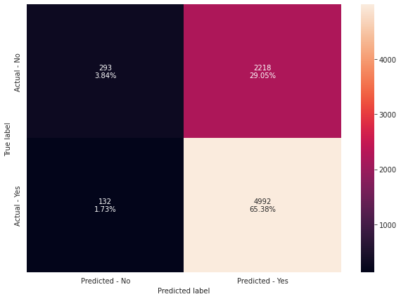

```python
make_confusion_matrix(abc_tuned,y_test)
```

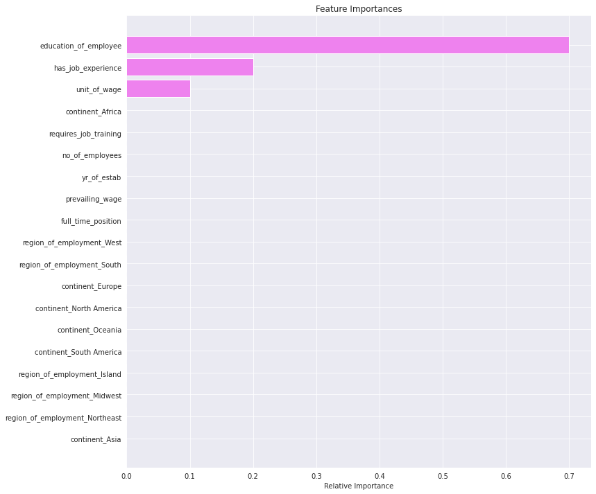

```python
importances = abc_tuned.feature_importances_
indices = np.argsort(importances)
feature_names = list(X.columns)

plt.figure(figsize=(12,12))
plt.title('Feature Importances')
plt.barh(range(len(indices)), importances[indices], color='violet', align='center')
plt.yticks(range(len(indices)), [feature_names[i] for i in indices])
plt.xlabel('Relative Importance')
plt.show()
```

Observations:

- Interestingly enough, our performance actually drops from the base AdaBoost model here. F1 decreased to 0.81 on the test set. This could be due to the fact that we limited the number of hyperparameter inputs to test because the model is very computationally exhaustive and was taking too long to run. Since we are seeing good performance on our other models, we are probably okay with that, but if we want to improve our model further, it might be worth it to come back and try to tune using additional hyperparameter values.
- There are not many important features in this model, but education level of the employee is once again the top predictor.

### Gradient Boost Classifier

```python
gbc = GradientBoostingClassifier(random_state=1)
gbc.fit(X_train,y_train)
```

```
GradientBoostingClassifier(random_state=1)
```

```python
# Using above defined function to get performance metrics on train and test set
gbc_score=get_metrics_score(gbc)
```

```
Accuracy on training set :  0.753873792948574
Accuracy on test set :  0.7538965291421087
Recall on training set :  0.8785046728971962
Recall on test set :  0.882903981264637
Precision on training set :  0.7801121495327102
Precision on test set :  0.7795967602963985
F1 score on training set :  0.8263899889117693
F1 score on test set :  0.8280406332936763
```

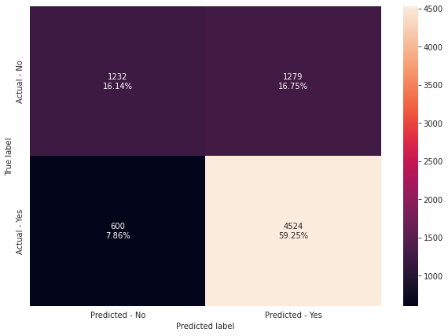

```python
make_confusion_matrix(gbc,y_test)
```

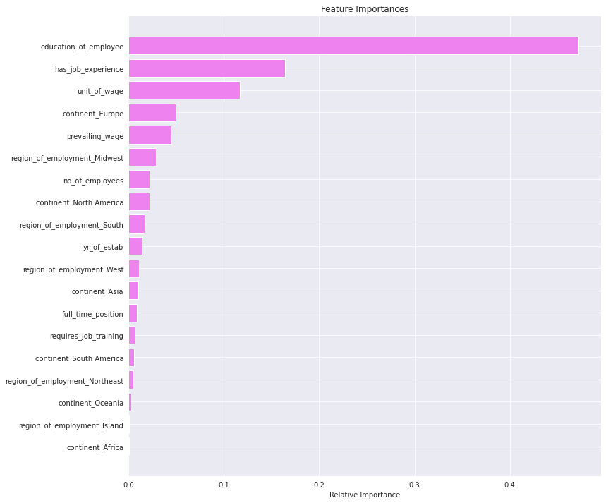

```python
importances = gbc.feature_importances_
indices = np.argsort(importances)
feature_names = list(X.columns)

plt.figure(figsize=(12,12))
plt.title('Feature Importances')
plt.barh(range(len(indices)), importances[indices], color='violet', align='center')
plt.yticks(range(len(indices)), [feature_names[i] for i in indices])
plt.xlabel('Relative Importance')
plt.show()
```

Observations:

- Similar to AdaBoost, we see that this model is performing as well as the other models with an F1 score ~0.83 and is not overfitting. That is nice to see without having to tune the hyperparameters!
- Education level of the employee is once again the most important feature.

#### Will tuning the hyperparameters improve the model performance?

```python
# trying adaboost classifier as the estimator for intial predictions
gbc_init = GradientBoostingClassifier(init=AdaBoostClassifier(random_state=1),random_state=1)
gbc_init.fit(X_train,y_train)
```

```
GradientBoostingClassifier(init=AdaBoostClassifier(random_state=1),
                           random_state=1)
```

```python
# Using above defined function to get performance metrics on train and test set
gbc_init_score=get_metrics_score(gbc_init)
```

```
Accuracy on training set :  0.7540422187289467
Accuracy on test set :  0.7545514079895219
Recall on training set :  0.8811147596194325
Recall on test set :  0.8856362217017955
Precision on training set :  0.778993598332589
Precision on test set :  0.7789220734637831
F1 score on training set :  0.8269131997945558
F1 score on test set :  0.8288584474885844
```

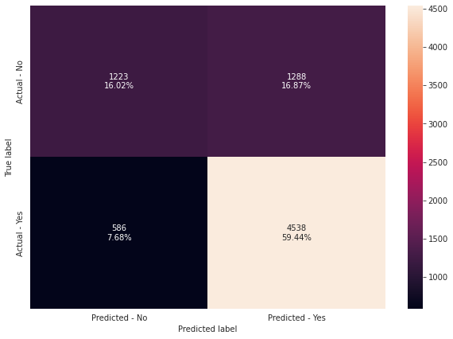

```python
make_confusion_matrix(gbc_init,y_test)
```

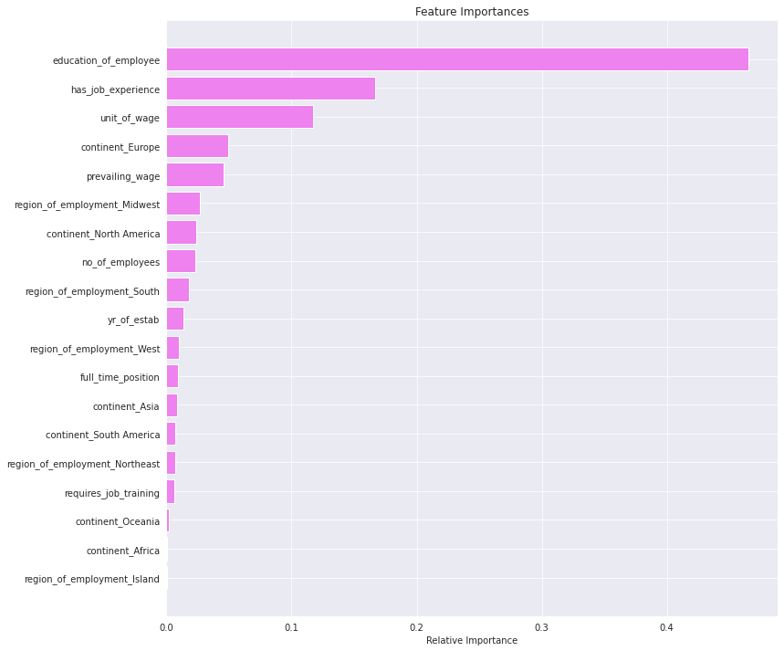

```python
importances = gbc_init.feature_importances_
indices = np.argsort(importances)
feature_names = list(X.columns)

plt.figure(figsize=(12,12))
plt.title('Feature Importances')
plt.barh(range(len(indices)), importances[indices], color='violet', align='center')
plt.yticks(range(len(indices)), [feature_names[i] for i in indices])
plt.xlabel('Relative Importance')
plt.show()
```

Observations:

- Using AdaBoost as the estimator for the initial predictions worked well as the F1 score on the test set increased slightly from the base GB model.
- We can see that once again education of the employee is our top feature.

```python
# Choose the type of classifier.
gbc_tuned = GradientBoostingClassifier(init=AdaBoostClassifier(random_state=1),random_state=1)

# Grid of parameters to choose from
## add from article
parameters = {
    "n_estimators": [100,200,250],
    "subsample":[0.8,0.9,1],
    "max_features":[0.7,0.8,1]
}

# Type of scoring used to compare parameter combinations
acc_scorer = metrics.make_scorer(metrics.recall_score)

# Run the grid search
grid_obj = GridSearchCV(gbc_tuned, parameters, scoring=acc_scorer,cv=5)
grid_obj = grid_obj.fit(X_train, y_train)

# Set the clf to the best combination of parameters
gbc_tuned = grid_obj.best_estimator_

# Fit the best algorithm to the data.
gbc_tuned.fit(X_train, y_train)
```

```
GradientBoostingClassifier(init=AdaBoostClassifier(random_state=1),
                           max_features=1, random_state=1, subsample=0.8)
```

```python
# Using above defined function to get performance metrics on train and test set
gbc_tuned_score=get_metrics_score(gbc_tuned)
```

```
Accuracy on training set :  0.7301257579160116
Accuracy on test set :  0.7360838244924689
Recall on training set :  0.9193399006483118
Recall on test set :  0.9227166276346604
Precision on training set :  0.7393689057421452
Precision on test set :  0.744918859303608
F1 score on training set :  0.8195909176205667
F1 score on test set :  0.8243396390898788
```

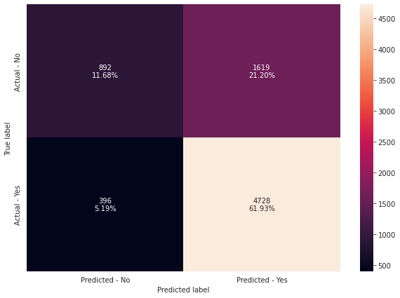

```python
make_confusion_matrix(gbc_tuned,y_test)
```

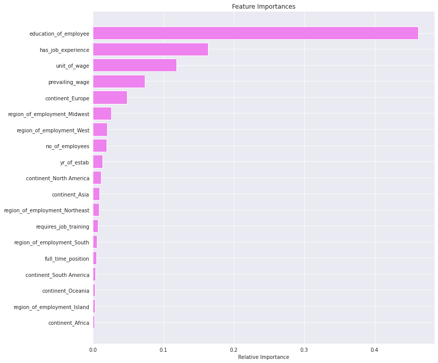

```python
importances = gbc_tuned.feature_importances_
indices = np.argsort(importances)
feature_names = list(X.columns)

plt.figure(figsize=(12,12))
plt.title('Feature Importances')
plt.barh(range(len(indices)), importances[indices], color='violet', align='center')
plt.yticks(range(len(indices)), [feature_names[i] for i in indices])
plt.xlabel('Relative Importance')
plt.show()
```

Observations:

- We can see that performance went down slightly from the GB model with the AdaBoost initial estimator.
- Once again, we may be able to improve this model performance further with additional hyperparameter tuning, but we will accept the tradeoff of a solid model without that computational exhaustion.
- Education of the employee is still our top feature.

## Model Performance Comparison and Conclusions

```python
# defining list of models
models = [dtree, dtree_tuned, bagging_estimator, bagging_estimator_tuned, rf_estimator, rf_estimator_tuned, abc, abc_tuned, gbc, gbc_init, gbc_tuned]

# defining empty lists to add train and test results
acc_train = []
acc_test = []
recall_train = []
recall_test = []
precision_train = []
precision_test = []
f1_train = []
f1_test = []

# looping through all the models to get the accuracy, precall and precision scores
for model in models:
    j = get_metrics_score(model,False)
    acc_train.append(np.round(j[0],2))
    acc_test.append(np.round(j[1],2))
    recall_train.append(np.round(j[2],2))
    recall_test.append(np.round(j[3],2))
    precision_train.append(np.round(j[4],2))
    precision_test.append(np.round(j[5],2))
    f1_train.append(np.round(j[6],2))
    f1_test.append(np.round(j[7],2))
```

```python
comparison_frame = pd.DataFrame({'Model':['Decision Tree with default parameters', 'Decision Tree tuned',
                                          'Bagging Classifier with default parameters','Bagging Classifier tuned',
                                          'Random Forest with default parameters','Random Forest tuned',
                                          'AdaBoost with default parameters','AdaBoost tuned',
                                          'Gradient Boosting with default parameters','Gradient Boosting with init=AdaBoost',
                                          'Gradient Boosting tuned'],
                                          'Train_Accuracy': acc_train,'Test_Accuracy': acc_test,
                                          'Train_Recall':recall_train,'Test_Recall':recall_test,
                                          'Train_Precision':precision_train,'Test_Precision':precision_test,
                                          'Train_F1':f1_train,'Test_F1':f1_test})
comparison_frame
```

|  | Model | Train_Accuracy | Test_Accuracy | Train_Recall | Test_Recall | Train_Precision | Test_Precision | Train_F1 | Test_F1 |
| --- | --- | --- | --- | --- | --- | --- | --- | --- | --- |
| 0 | Decision Tree with default parameters | 1.00 | 0.66 | 1.00 | 0.74 | 1.00 | 0.76 | 1.00 | 0.75 |
| 1 | Decision Tree tuned | 0.75 | 0.75 | 0.87 | 0.88 | 0.78 | 0.78 | 0.82 | 0.83 |
| 2 | Bagging Classifier with default parameters | 0.99 | 0.71 | 0.99 | 0.78 | 0.99 | 0.78 | 0.99 | 0.78 |
| 3 | Bagging Classifier tuned | 0.67 | 0.67 | 1.00 | 1.00 | 0.67 | 0.67 | 0.80 | 0.80 |
| 4 | Random Forest with default parameters | 1.00 | 0.73 | 1.00 | 0.84 | 1.00 | 0.77 | 1.00 | 0.81 |
| 5 | Random Forest tuned | 0.76 | 0.75 | 0.90 | 0.90 | 0.77 | 0.77 | 0.83 | 0.83 |
| 6 | AdaBoost with default parameters | 0.73 | 0.74 | 0.88 | 0.89 | 0.76 | 0.76 | 0.82 | 0.82 |
| 7 | AdaBoost tuned | 0.69 | 0.69 | 0.97 | 0.97 | 0.69 | 0.69 | 0.81 | 0.81 |
| 8 | Gradient Boosting with default parameters | 0.75 | 0.75 | 0.88 | 0.88 | 0.78 | 0.78 | 0.83 | 0.83 |
| 9 | Gradient Boosting with init=AdaBoost | 0.75 | 0.75 | 0.88 | 0.89 | 0.78 | 0.78 | 0.83 | 0.83 |
| 10 | Gradient Boosting tuned | 0.73 | 0.74 | 0.92 | 0.92 | 0.74 | 0.74 | 0.82 | 0.82 |

## Actionable Insights and Recommendations

- We have three really solid models to choose from to put into production: Random Forest tuned, Gradient Boosting with default parameters, and Gradient Boosting with init=AdaBoost. All have an F1 score of 0.83 on both the training and test sets, so they are not overfitting.
- All three of our models show the education level of the employee to be the most imporant feature when trying to predict whether a visa will be certified or not.
- Whether an applicant has job experience or not and the prevailing wage are also important features.
- The profile of a candidate who is likely to be approved is as follows:
  - High level of education - the higher the better. Applicants with PhDs are more likely to be approved than those with other degrees or no degree.
  - High prevailing wage - positions that pay well are more likely for an applicant to get approved. Likely because jobs that pay well require highly advanced skills or education that not a lot of people may have.
  - Has prior job experience - if an applicant has a high level of education, and is applying for a position with a high prevailing wage, then they are most likely to get approved for a visa if they also have prior job experience.

```python
%%shell
jupyter nbconvert --to html /content/KD_DSBA_Project_ET_EasyVisa_Fullcode.ipynb
```

```
[NbConvertApp] Converting notebook /content/KD_DSBA_Project_ET_EasyVisa_Fullcode.ipynb to html
[NbConvertApp] Writing 1627326 bytes to /content/KD_DSBA_Project_ET_EasyVisa_Fullcode.html
```